# Assignment 2

Anvit Hugar - 10516794

[figure not shown]

## Introduction:

My answers to Assignment 2 for B9DA100 are found below.

### Question 1:

Load the MASS library, and access the Cars93 dataset.

```r
install.packages("MASS", repos = "http://cran.us.r-project.org")
library(MASS)
data("Cars93")
head(Cars93)
```

```
##   Manufacturer   Model    Type Min.Price Price Max.Price MPG.city
## 1        Acura Integra   Small      12.9  15.9      18.8       25
## 2        Acura  Legend Midsize      29.2  33.9      38.7       18
## 3         Audi      90 Compact      25.9  29.1      32.3       20
## 4         Audi     100 Midsize      30.8  37.7      44.6       19
## 5          BMW    535i Midsize      23.7  30.0      36.2       22
## 6        Buick Century Midsize      14.2  15.7      17.3       22
##   MPG.highway            AirBags DriveTrain Cylinders EngineSize
## 1          31               None      Front         4        1.8
## 2          25 Driver & Passenger      Front         6        3.2
## 3          26        Driver only      Front         6        2.8
## 4          26 Driver & Passenger      Front         6        2.8
## 5          30        Driver only       Rear         4        3.5
## 6          31        Driver only      Front         4        2.2
##   Horsepower  RPM Rev.per.mile Man.trans.avail Fuel.tank.capacity
```

[output cut: 20 more lines]

#### 1.1

In 1.1, we need to Produce two different plots from the Cars93 dataset - each plot can be contained in a single panel, or a plot can be spread over two or more panels if necessary (these are called multipanel plots - e.g., side-by-side barcharts). Your plots should be neat and presentable, clearly labelled, and use colour and relevant legends where appropriate. Your two plots must be of different types

**plot1**

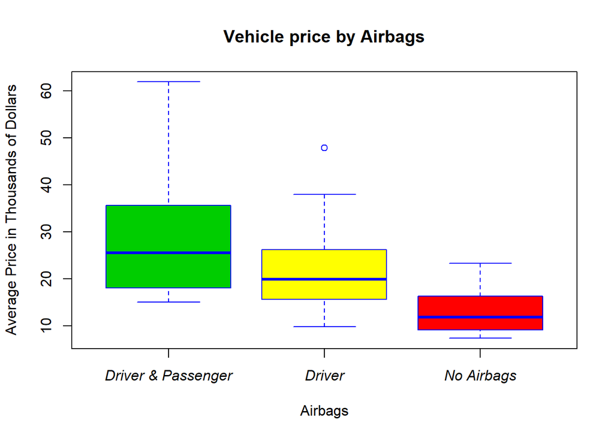

```r
colors=c(59,535,"red")                    #assigning coral2,peru and red to colors
boxplot(Cars93$Price~Cars93$AirBags,xlab='Airbags', xaxt="n",   #creating boxplot for price against Airbags
        ylab='Average Price in Thousands of Dollars',
        main='Vehicle price by Airbags',font.main=3, col=colors, cex.lab=1,border="blue")
axis(side=1,                                  #change the font style to present the
     at=1:3,                                  #plot neat.
     labels = c("Driver & Passenger", "Driver", "No Airbags"),
     font.axis=3)
```

**plot2**

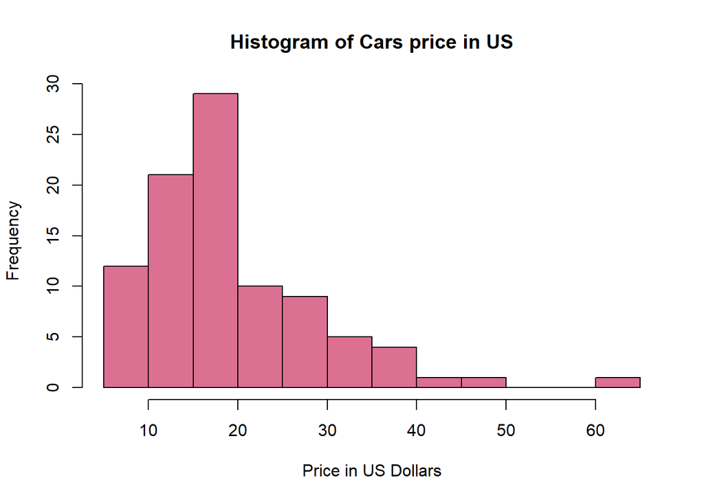

```r
hist(Cars93$Price, breaks = 10,           #creating the histgram for car price with 10 break between the price
     xlab = "Price in US Dollars",
     main = "Histogram of Cars price in US",
     col = "palevioletred")
```

#### 1.2

In 1.2, we need to Write 3 to 4 sentences for each plot to explain what it tells us about the dataset.

In the question 1.1, The first plot represents the price of the cars depending on the Airbags. We can obverse that the price of the cars are high for cars having Airbags for both Driver and Passenger. similiarly for Cars without Airbags price is comparitively low.

For the second plot, I have created a Histogram of cars price. we can observe that more number of cars price are in the range of 15 to 20 thousand dollar and there are fewer cars in the range above 60 thousand dollars. From the plot we can say that almost 30 cars are in the range 15 to 20 thousand dollars.

### Question 2

#### 2.1

In 2.1, Load the DAAG library and access the leafshape dataset contained in it. Load the help file and read about the dataset. In what country is the data collected?

```r
install.packages("DAAG", repos = "http://cran.us.r-project.org")
library(DAAG)
data("leafshape")
help(leafshape)
```

The data was collected from **Australia.**

#### 2.2

In 2.2, A researcher is interested in seeing if there is a relationship between the blade length of the biomass and the location where it is growing. so, we need to create a plot containing boxplots of the blade length variable, grouped by location.

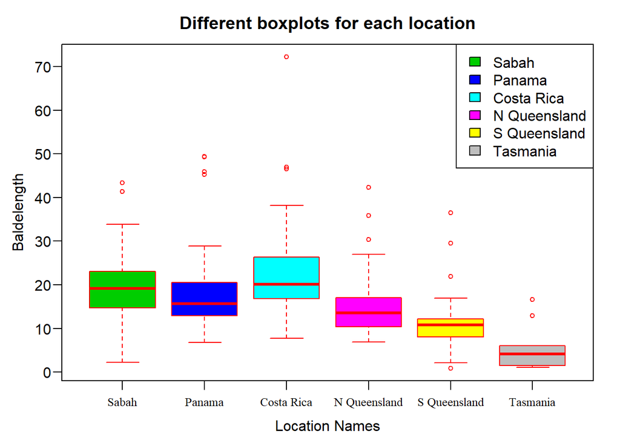

```r
leafy_ln <- table(leafshape$bladelen, leafshape$location)
par(mar = c(3.5, 3.5, 2.5, 1.5), mgp = c(2, 0.6, 0), las = 1)
boxplot(leafshape$bladelen~leafshape$location,xaxt="n",     #creating the boxplot for bladelength and location
        main="Different boxplots for each location",
        xlab="Location Names", ylab="Baldelength",
        col=c(3,4,5,6,7,8), cex= 0.7, font.lab=4,
        border="362")
legend("topright", legend = c("Sabah","Panama","Costa Rica","N Queensland", "S Queensland", "Tasmania"),
 fill =c(3,4,5,6,7,8))
  axis(side = 1,                  #using axis to present the plot neat and clear
       at = 1:6,
       labels = c("Sabah","Panama","Costa Rica","N Queensland", "S Queensland", "Tasmania"),
       cex.axis=.8,
       cex= 1,
       col.axis="black",
       font.axis=6)
```

#### 2.3

In 2.3, we need to Comment on the resulting graph. What information does it illustrate?